# Assignment 4

Rudklao Raviyan UPI:rrav628

2023-10-05

# Task 1

```r
# a)
set.seed(622)

# b)
bank <- read.csv("D:/Documents/Uni_UoA/Stats 369/Assignments/Assignment_4/bank_marketing.csv",  sep = ";")

bank$job <- as.factor(bank$job)
bank$marital <- as.factor(bank$marital)
bank$education <- as.factor(bank$education)
bank$default <- as.factor(bank$default)
bank$housing <- as.factor(bank$housing)
bank$loan <- as.factor(bank$loan)
bank$contact <- as.factor(bank$contact)
bank$day_of_week <- as.factor(bank$day_of_week)
bank$month <- as.factor(bank$month)
bank$poutcome <- as.factor(bank$poutcome)

summary(bank)
```

```
##       age                 job            marital
##  Min.   :17.00   admin.     :10421   divorced: 4610
##  1st Qu.:32.00   blue-collar: 9246   married :24910
##  Median :38.00   technician : 6741   single  :11567
##  Mean   :40.02   services   : 3969   unknown :   80
##  3rd Qu.:47.00   management : 2924
##  Max.   :98.00   retired    : 1717
##                  (Other)    : 6149
##                education        default         housing           loan
##  basic.4y           : 4176   no     :32577   no     :18612   no     :33932
##  basic.6y           : 2292   unknown: 8590   unknown:  990   unknown:  990
##  basic.9y           : 6045                   yes    :21565   yes    : 6245
##  high.school        : 9514
##  professional.course: 5241
##  university.degree  :12168
##  unknown            : 1731
##       contact          month       day_of_week    duration
##  cellular :26126   may    :13766   fri:7823    Min.   :   0.0
##  telephone:15041   jul    : 7169   mon:8513    1st Qu.: 102.0
##                    aug    : 6171   thu:8617    Median : 180.0
##                    jun    : 5318   tue:8082    Mean   : 258.3
##                    nov    : 4097   wed:8132    3rd Qu.: 319.0
##                    apr    : 2630               Max.   :4918.0
##                    (Other): 2016
##     campaign          pdays          previous            poutcome
##  Min.   : 1.000   Min.   :  0.0   Min.   :0.000   failure    : 4250
##  1st Qu.: 1.000   1st Qu.:999.0   1st Qu.:0.000   nonexistent:35545
##  Median : 2.000   Median :999.0   Median :0.000   success    : 1372
##  Mean   : 2.568   Mean   :962.5   Mean   :0.173
##  3rd Qu.: 3.000   3rd Qu.:999.0   3rd Qu.:0.000
##  Max.   :56.000   Max.   :999.0   Max.   :7.000
##
##   emp_var_rate      cons_price_idx  cons_conf_idx     euribor3m
##  Min.   :-3.40000   Min.   :92.20   Min.   :-50.8   Min.   :0.634
##  1st Qu.:-1.80000   1st Qu.:93.08   1st Qu.:-42.7   1st Qu.:1.344
##  Median : 1.10000   Median :93.75   Median :-41.8   Median :4.857
##  Mean   : 0.08192   Mean   :93.58   Mean   :-40.5   Mean   :3.621
##  3rd Qu.: 1.40000   3rd Qu.:93.99   3rd Qu.:-36.4   3rd Qu.:4.961
##  Max.   : 1.40000   Max.   :94.77   Max.   :-26.9   Max.   :5.045
##
##   nr_employed        y
##  Min.   :4964   Length:41167
##  1st Qu.:5099   Class :character
##  Median :5191   Mode  :character
##  Mean   :5167
##  3rd Qu.:5228
##  Max.   :5228
##
```

## c)

`Duration` was discarded because in the data dictionary specifically say that to include this variable for benchmark only. Also, this variable does not really seems to have relationship regards to the clients features. In addition, at the end of the call, the result is known straight away. So it seems to be sensible to discard this variable.

`poutcome` and `pdays` was stated on the data dictionary that it has missing values so it was also being discarded.

# Task 2

## a)

```r
# a)

# discard  variables
bank_edited <- bank[c(-11, -13, -15)]

# convert y from yes/no to 0/1
bank_edited$response <- ifelse(bank_edited$y == "yes", 1, 0)
bank_edited$response <- as.numeric(bank_edited$response)
bank_edited <- bank_edited[-which(names(bank_edited) == 'y')]
colnames(bank_edited)[18] = "y"


# subsetting data into 2 categories
response_no <- subset(bank_edited, bank_edited[,18] == 0)
response_yes <- subset(bank_edited, bank_edited[,18] == 1)

# create training/testing set
sample <- sample(nrow(response_no), nrow(response_no) * 0.1)
no_testing <- response_no[sample,]
no_training<- response_no[-sample,]

sample2 <- sample(nrow(response_yes), nrow(response_yes) * 0.1)
yes_testing <- response_yes[sample2,]
yes_training<- response_yes[-sample2,]

test.df <- rbind(no_testing, yes_testing)
train.df <- rbind(no_training, yes_training)
```

## b)

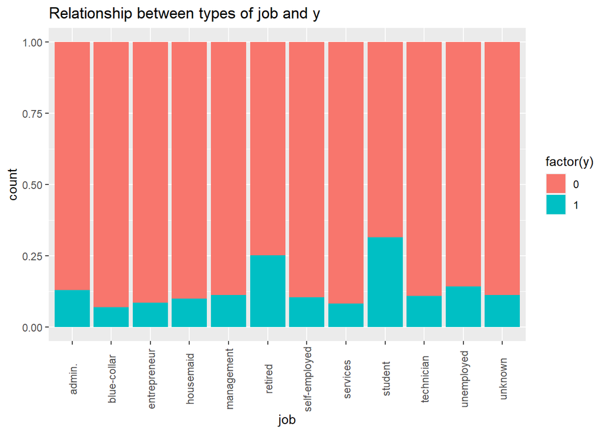

```r
#qualitative

p1 <- ggplot(data = bank_edited, aes(x = job, fill = factor(y))) +
  geom_bar(position = "fill") +
  theme(axis.text.x = element_text(angle = 90, vjust = 0.5)) +
  labs(title = "Relationship between types of job and y")

p2 <- ggplot(data = bank_edited, aes(x = education, fill = factor(y))) +
  geom_bar(position = "fill") +
  theme(axis.text.x = element_text(angle = 90, vjust = 0.5))  +
  labs(title = "Relationship between education level and y")

p3 <- ggplot(data = bank_edited, aes(x = marital, fill = factor(y))) +
  geom_bar(position = "fill") +
  labs(title = "Relationship between marital status and y")

p4 <- ggplot(data = bank_edited, aes(x = default, fill = factor(y))) +
  geom_bar(position = "fill") +
  labs(title = "Relationship between credit in default and y")

p5 <- ggplot(data = bank_edited, aes(x = housing, fill = factor(y))) +
  geom_bar(position = "fill") +
  labs(title = "Relationship between housing loan and y")

p6 <- ggplot(data = bank_edited, aes(x = loan, fill = factor(y))) +
  geom_bar(position = "fill") +
  labs(title = "Relationship between personal loan and y")

p7 <- ggplot(data = bank_edited, aes(x = day_of_week, fill = factor(y))) +
  geom_bar(position = "fill") +
  labs(title = "Relationship between last contact day of the week and y")

p8 <- ggplot(data = bank_edited, aes(x = month, fill = factor(y))) +
  geom_bar(position = "fill") +
  labs(title = "Relationship between last contact month of year and y")

p10 <- ggplot(data = bank_edited, aes(x = contact, fill = factor(y))) +
  geom_bar(position = "fill") +
  labs(title = "Relationship between communication type and y")


par(mfrow = c(2,5))
p1
```

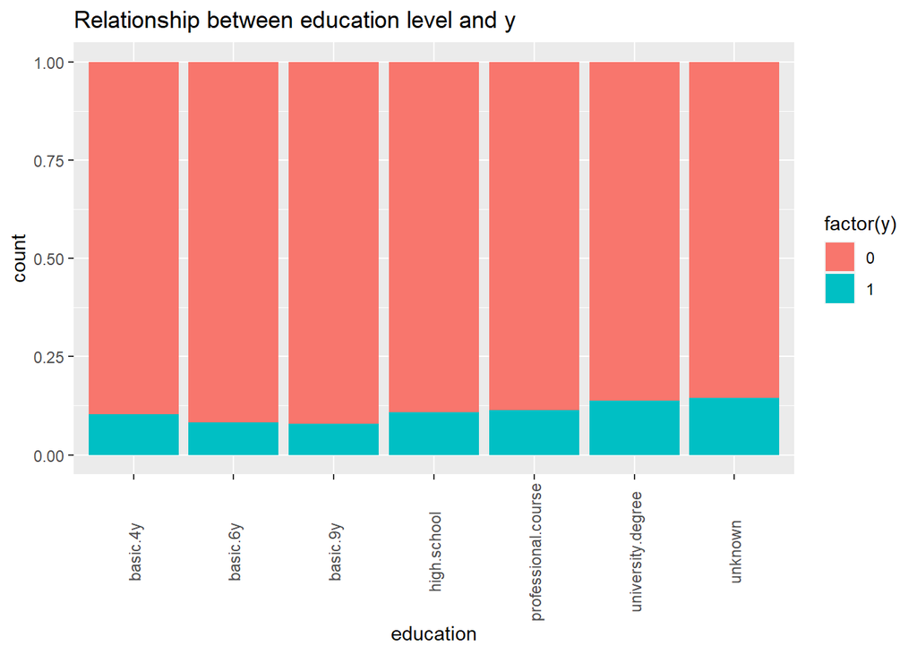

```r
p2
```

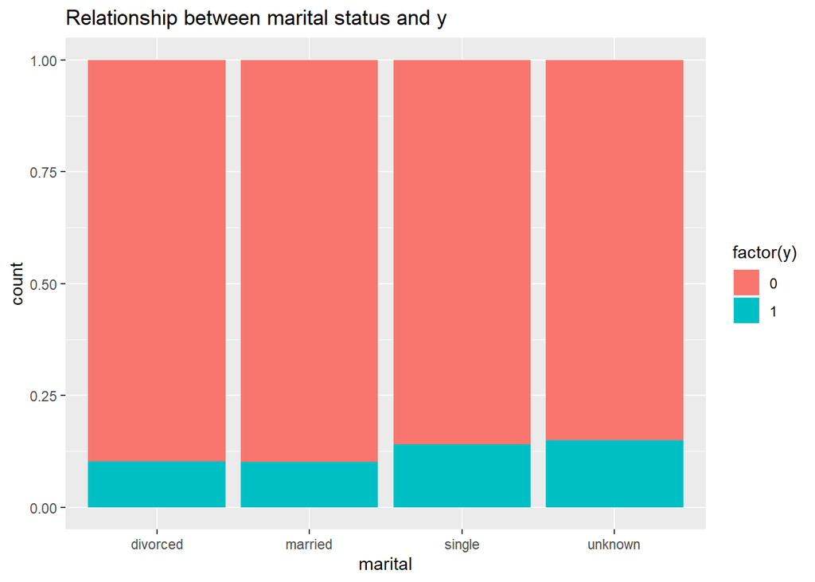

```r
p3
```

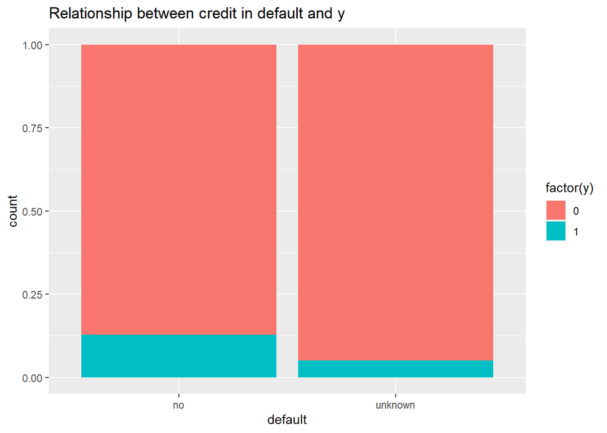

```r
p4
```

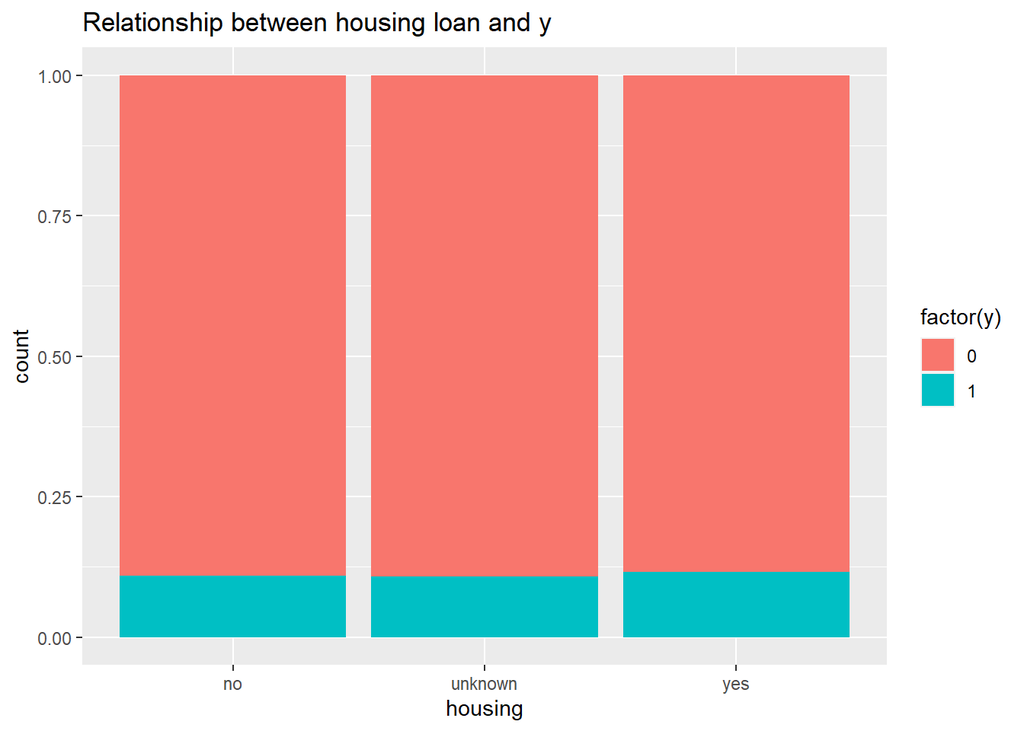

```r
p5
```

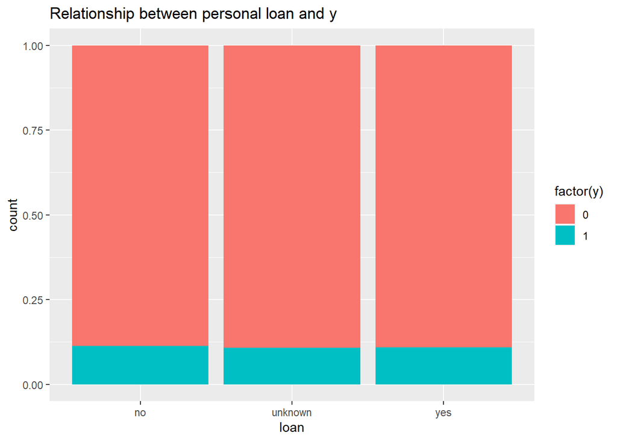

```r
p6
```

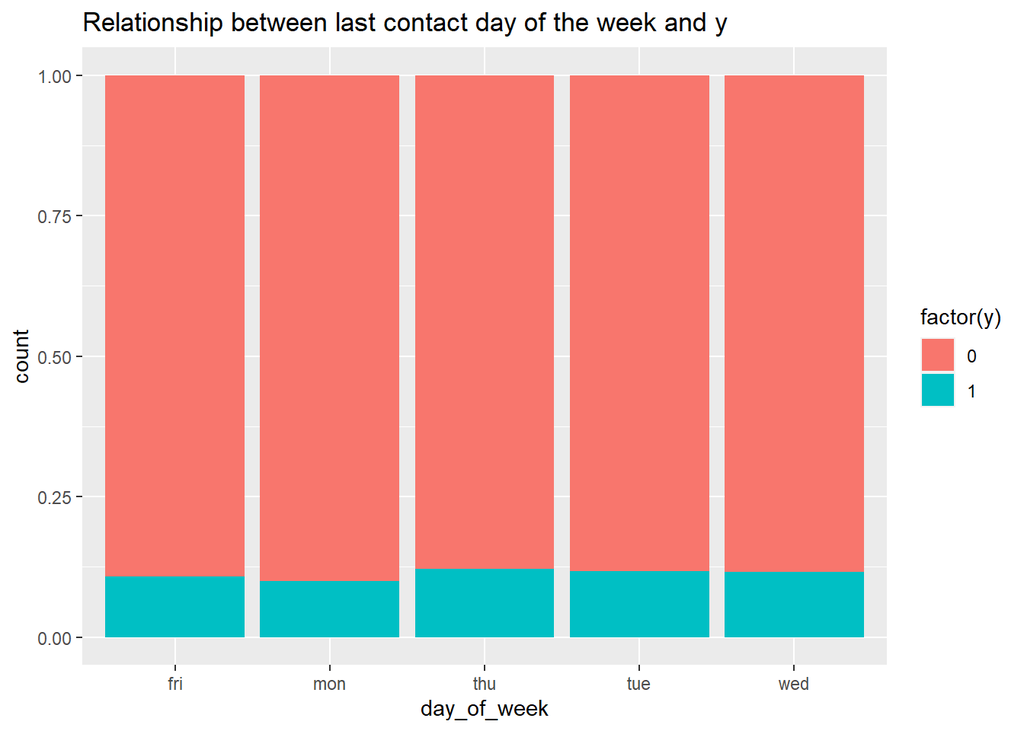

```r
p7
```

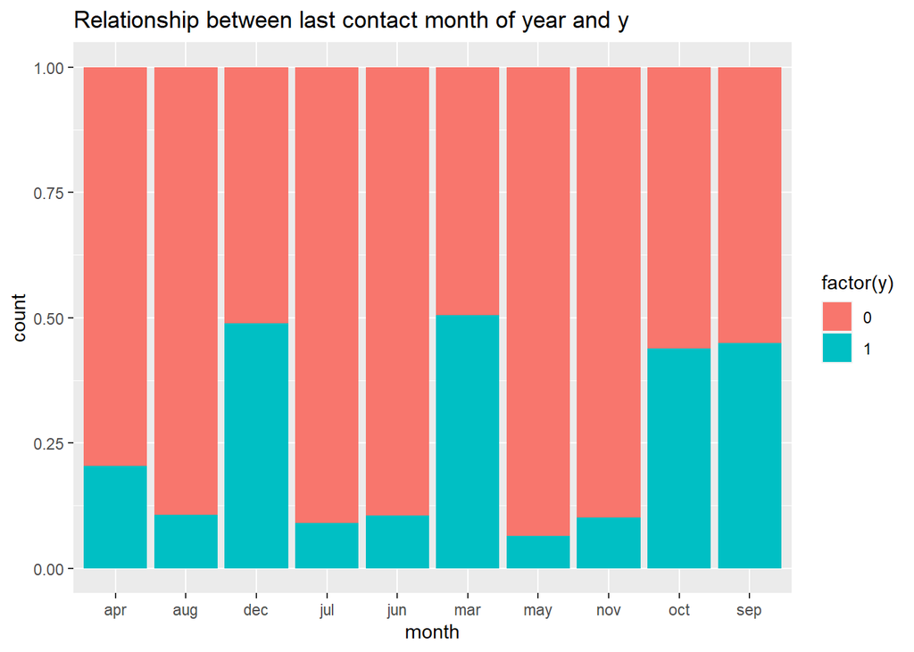

```r
p8
```

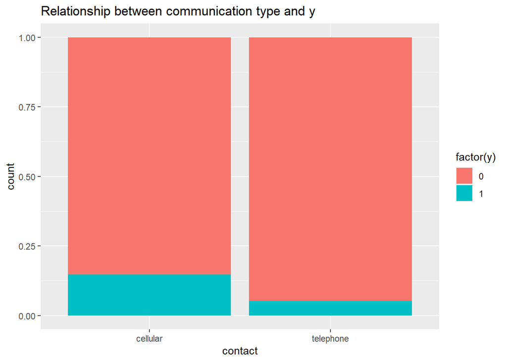

```r
p10
```

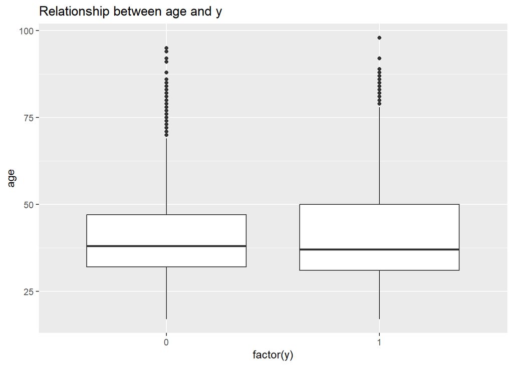

```r
# quantitative

p11 <-  ggplot(data = bank_edited, aes(x = factor(y), y = age)) +
  geom_boxplot() +
  labs(title = "Relationship between age and y")

p12 <-  ggplot(data = bank_edited, aes(x = factor(y), y = campaign)) +
  geom_boxplot() +
  labs(title = "Relationship between number of contacts performed during this campaign and for this client and y")

p15 <- ggplot(data = bank_edited, aes(x = factor(y), y = previous)) +
  geom_boxplot() +
  labs(title = "Relationship between number of contacts performed before this campaign and for this client and y")

p16 <- ggplot(data = bank_edited, aes(x = factor(y), y = emp_var_rate)) +
  geom_boxplot() +
  labs(title = "Relationship between employment variation rate and y")


p18 <- ggplot(data = bank_edited, aes(x = factor(y), y = cons_price_idx)) +
  geom_boxplot() +
  labs(title = "Relationship between consumer price index and y")


p19 <- ggplot(data = bank_edited, aes(x = factor(y), y = cons_conf_idx)) +
  geom_boxplot() +
  labs(title = "Relationship between consumer confidence index and y")


p20 <- ggplot(data = bank_edited, aes(x = factor(y), y = euribor3m)) +
  geom_boxplot() +
  labs(title = "Relationship between  euribor 3 month rate and y")

p21 <- ggplot(data = bank_edited, aes(x = factor(y), y = nr_employed)) +
  geom_boxplot() +
  labs(title = "Relationship between number of employees and y")

p11
```

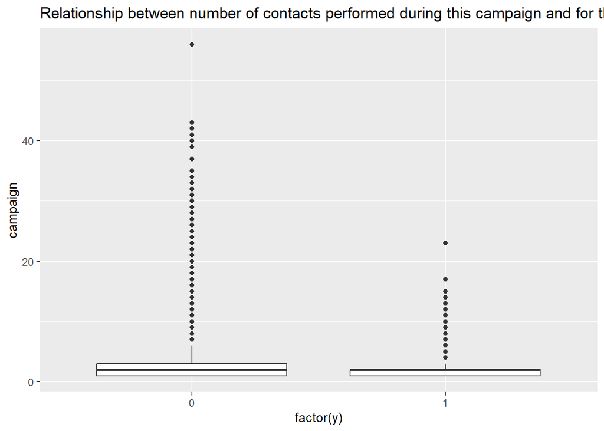

```r
p12
```

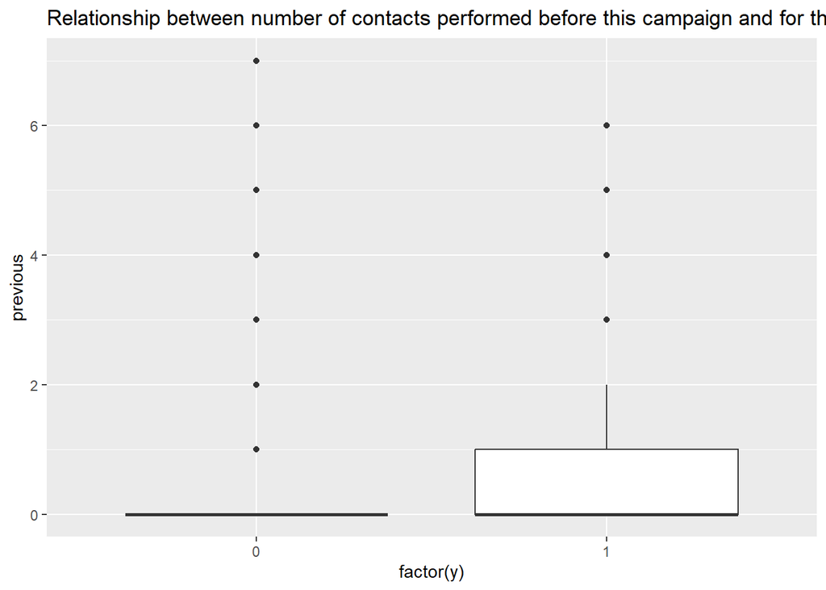

```r
p15
```

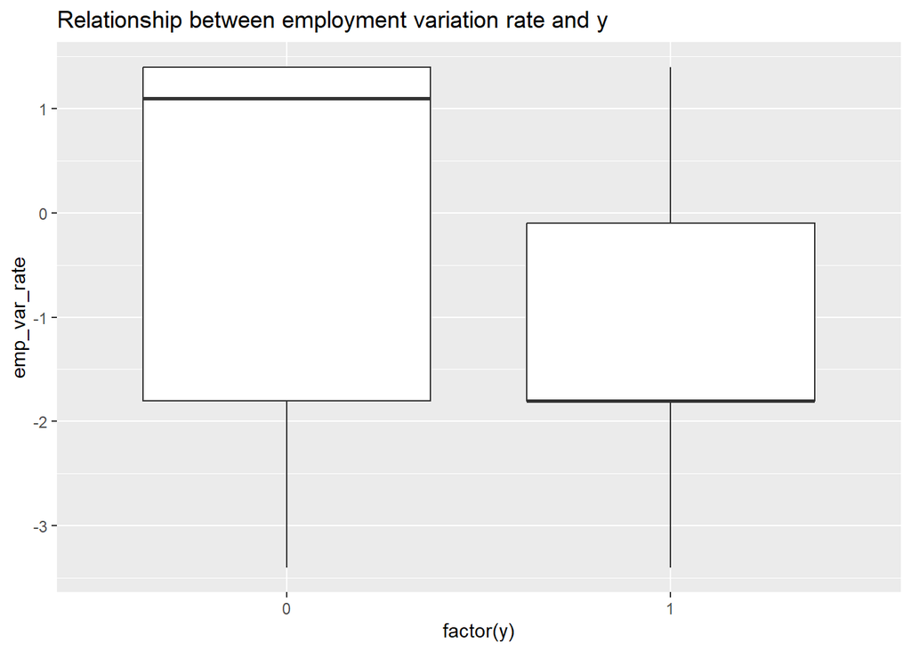

```r
p16
```

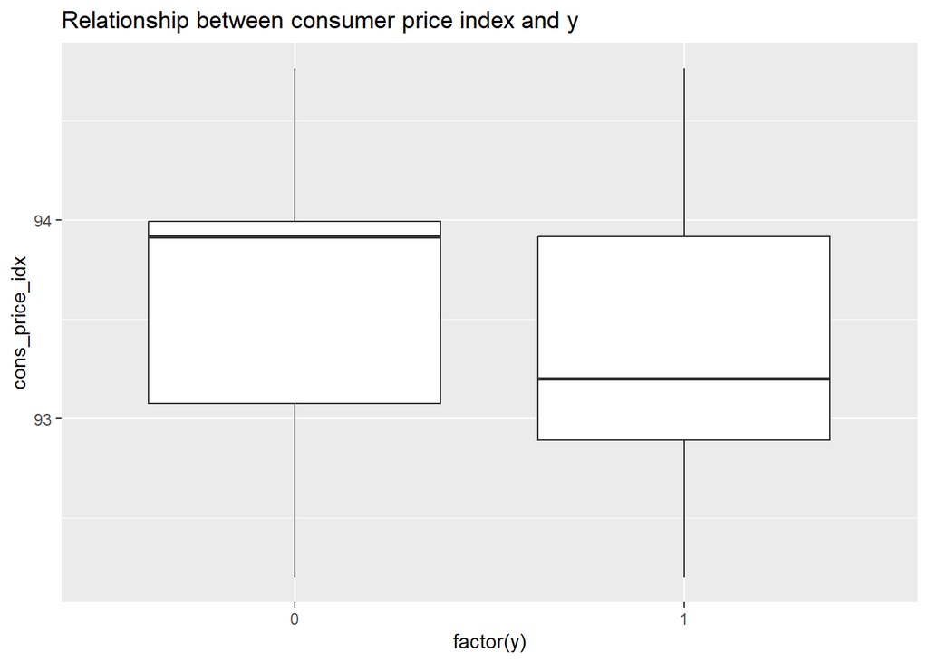

```r
p18
```

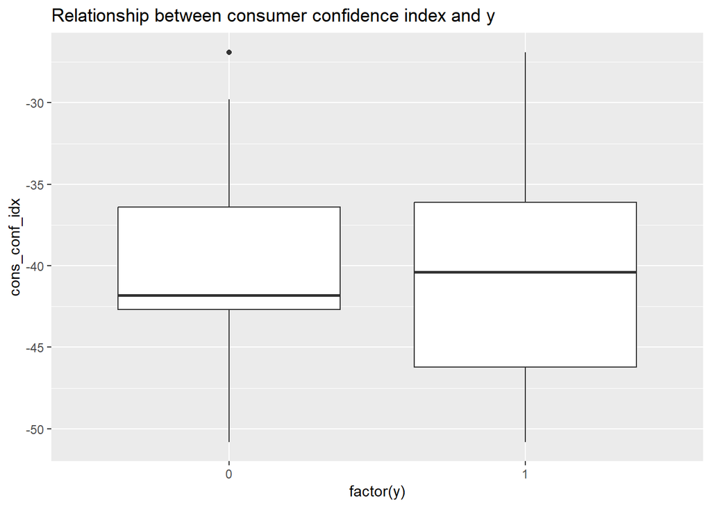

```r
p19
```

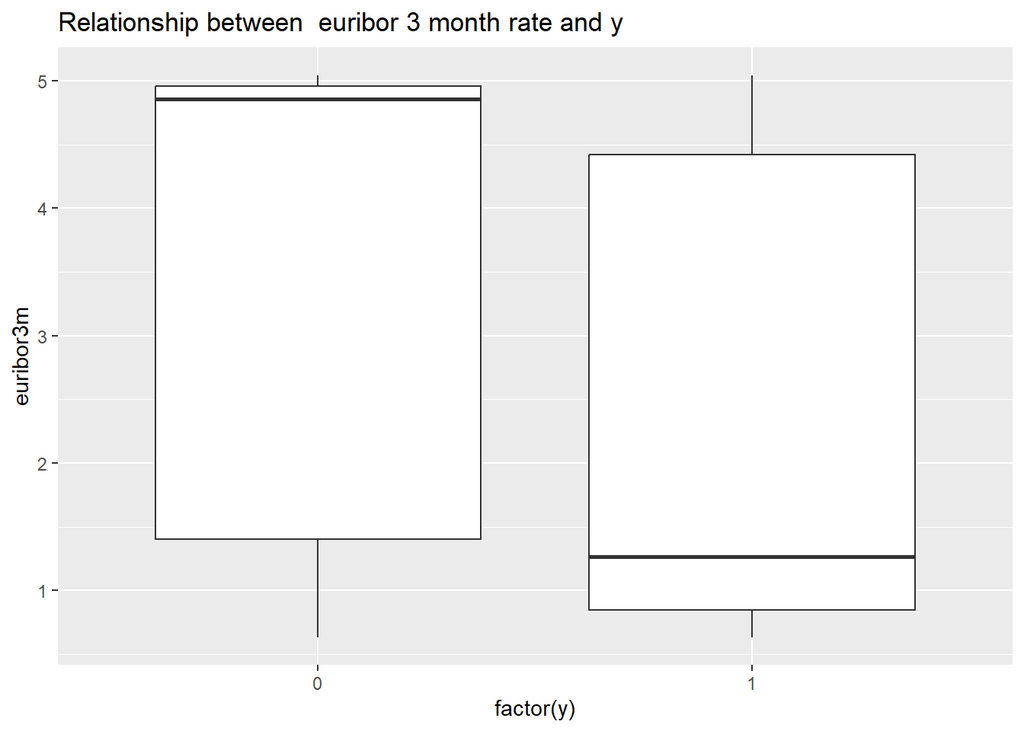

```r
p20
```

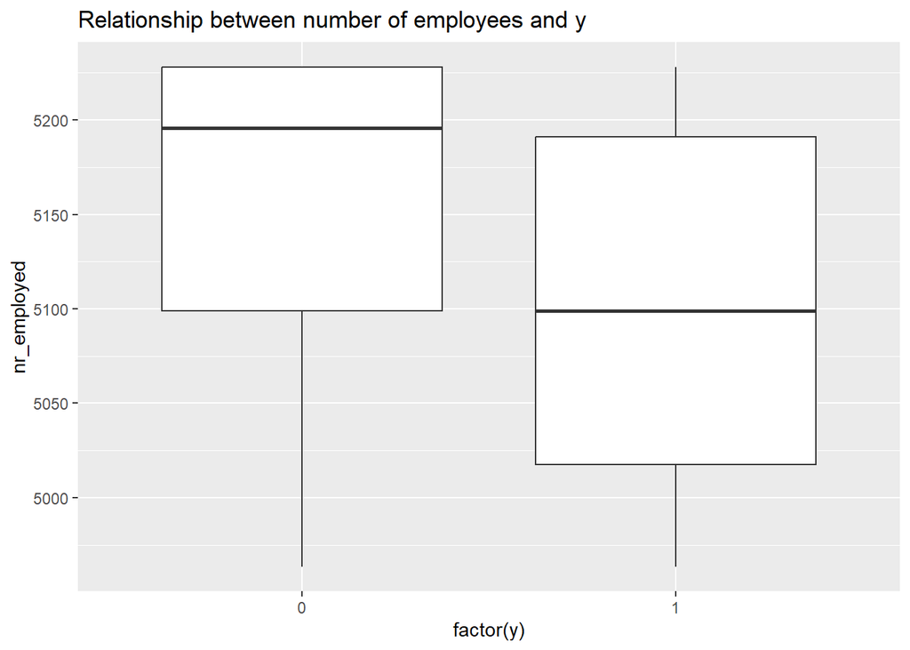

```r
p21
```

## c)

plot p1 - **job vs y**: The proportion of clients across different job categories who subscribed to term deposit varies across the groups. This suggests that job could influence the decision to subscribe to term deposit.

p2 - **education vs y**: The proportion of clients across different education level who subscribe to term deposit slightly varies across the groups. This suggests that education may not have that strong influence on the decision.

p3 - **marital vs y**: The proportion of clients across marriage status group. The chart shows that there are a slight difference proportion of clients who subscribe to the term deposit. The divorced and married group have almost the same proportion where the single and unknown are just slightly higher. This suggests that the marital might have small influence on the decision.

p4 - **default vs y**: the proportion of the clients who has no credit on default have higher proportion on subscribe to the term deposit than the unknown group.

p5/p6 - **house loan vs y**: and loan vs y: This chart shows that the proportion of the clients who subscribe to the term deposit is no difference across the groups. This suggests that house loan and loan variables may not have influence on the decision to subscribe to term deposit.

p7 - **day of the week vs y**: The proportion of the days that the bank calls the clients have a slight variations across the days. However, the differences are very small. This sugguests that the day of the week variables may have small influence on the decision.

p8 - **month vs y**: There are large variations on the proportions across the months. This suggests that month could influence the decision on subscribe to term deposit.

p10 - **contact vs y**: here are large variations on the proportions across the months method of contact. This suggests that contact could influence the decision on subscribe to term deposit.

p11/p12/p15: **relationship between age, campaign and previous to y** respectively. From the boxplots, the median is similar across the group that subscribe and not subscribe to the term deposit. Hence it suggests that these variable, age, campaign and previous may not have influence on the decision to subscribe to term deposit.

## d)

`euribor3m`, `emp_var_rate` and `month` may be the most important variables in predicting the term deposit subscription. The `euribor3m` and `emp_var_rate` has a large different across the subscribe and not subscribe group. These 2 variables relate to the interest rate and the employment situation. From the charts, given the large difference, this 2 variables could contribute significantly to the prediction.

Lastly, month variable. From the chart, there are large variations across different month that the clients were being contacted. Some months have proportion of people agree to subscribed to the term deposit than other months. Hence, month could be an important predictor variable.

# Task 3

## a)

```r
# a i)
bank.glm <- glm(y ~ ., data = train.df, family = "binomial")
summary(bank.glm)
```

```
##
## Call:
## glm(formula = y ~ ., family = "binomial", data = train.df)
##
## Coefficients: (1 not defined because of singularities)
##                                Estimate Std. Error z value Pr(>|z|)
## (Intercept)                  -2.229e+02  3.431e+01  -6.496 8.26e-11 ***
## age                           1.692e-04  2.205e-03   0.077 0.938818
## jobblue-collar               -1.853e-01  7.180e-02  -2.581 0.009839 **
## jobentrepreneur              -4.578e-02  1.104e-01  -0.415 0.678445
## jobhousemaid                 -3.168e-02  1.299e-01  -0.244 0.807320
## jobmanagement                -7.455e-02  7.775e-02  -0.959 0.337617
## jobretired                    1.817e-01  9.771e-02   1.860 0.062927 .
## jobself-employed             -1.853e-01  1.087e-01  -1.704 0.088374 .
## jobservices                  -1.531e-01  7.786e-02  -1.967 0.049186 *
## jobstudent                    2.121e-01  1.028e-01   2.062 0.039174 *
## jobtechnician                -4.760e-04  6.406e-02  -0.007 0.994072
## jobunemployed                 1.219e-02  1.156e-01   0.105 0.916013
## jobunknown                   -2.490e-01  2.282e-01  -1.091 0.275228
## maritalmarried                3.220e-02  6.233e-02   0.517 0.605383
## maritalsingle                 9.389e-02  7.101e-02   1.322 0.186129
## maritalunknown                4.518e-01  3.903e-01   1.158 0.247015
## educationbasic.6y             1.539e-01  1.073e-01   1.434 0.151536
## educationbasic.9y            -2.085e-02  8.604e-02  -0.242 0.808550
## educationhigh.school          2.259e-02  8.350e-02   0.271 0.786751
## educationprofessional.course  3.230e-02  9.181e-02   0.352 0.724960
## educationuniversity.degree    1.158e-01  8.358e-02   1.385 0.165915
## educationunknown              8.002e-02  1.098e-01   0.729 0.465996
## defaultunknown               -2.791e-01  6.057e-02  -4.608 4.07e-06 ***
## housingunknown               -1.250e-01  1.236e-01  -1.011 0.311938
## housingyes                   -3.871e-02  3.733e-02  -1.037 0.299722
## loanunknown                          NA         NA      NA       NA
## loanyes                      -3.864e-02  5.173e-02  -0.747 0.455037
## contacttelephone             -7.513e-01  6.974e-02 -10.772  < 2e-16 ***
## monthaug                      4.502e-01  1.098e-01   4.101 4.12e-05 ***
## monthdec                      4.744e-01  1.898e-01   2.499 0.012438 *
## monthjul                      3.950e-02  8.630e-02   0.458 0.647173
## monthjun                     -6.492e-01  1.138e-01  -5.705 1.16e-08 ***
## monthmar                      1.407e+00  1.349e-01  10.426  < 2e-16 ***
## monthmay                     -4.527e-01  7.429e-02  -6.093 1.11e-09 ***
```

[output cut: 9 more lines]

```
## emp_var_rate                 -1.478e+00  1.267e-01 -11.670  < 2e-16 ***
## cons_price_idx                2.094e+00  2.259e-01   9.271  < 2e-16 ***
## cons_conf_idx                 3.335e-02  7.162e-03   4.656 3.22e-06 ***
## euribor3m                     2.677e-01  1.185e-01   2.260 0.023838 *
## nr_employed                   4.930e-03  2.799e-03   1.762 0.078136 .
## ---
## Signif. codes:  0 '***' 0.001 '**' 0.01 '*' 0.05 '.' 0.1 ' ' 1
##
## (Dispersion parameter for binomial family taken to be 1)
##
##     Null deviance: 26082  on 37050  degrees of freedom
## Residual deviance: 20949  on 37004  degrees of freedom
## AIC: 21043
##
## Number of Fisher Scoring iterations: 6
```

```r
# ii Ridge
library(glmnet)
```

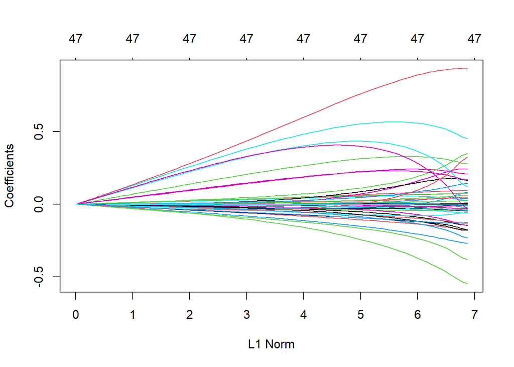

```r
X <- model.matrix(y ~ ., data = train.df)
y <- train.df$y
bank.ridge <- glmnet(X, y, alpha = 0, family = 'binomial')
plot(bank.ridge)
```

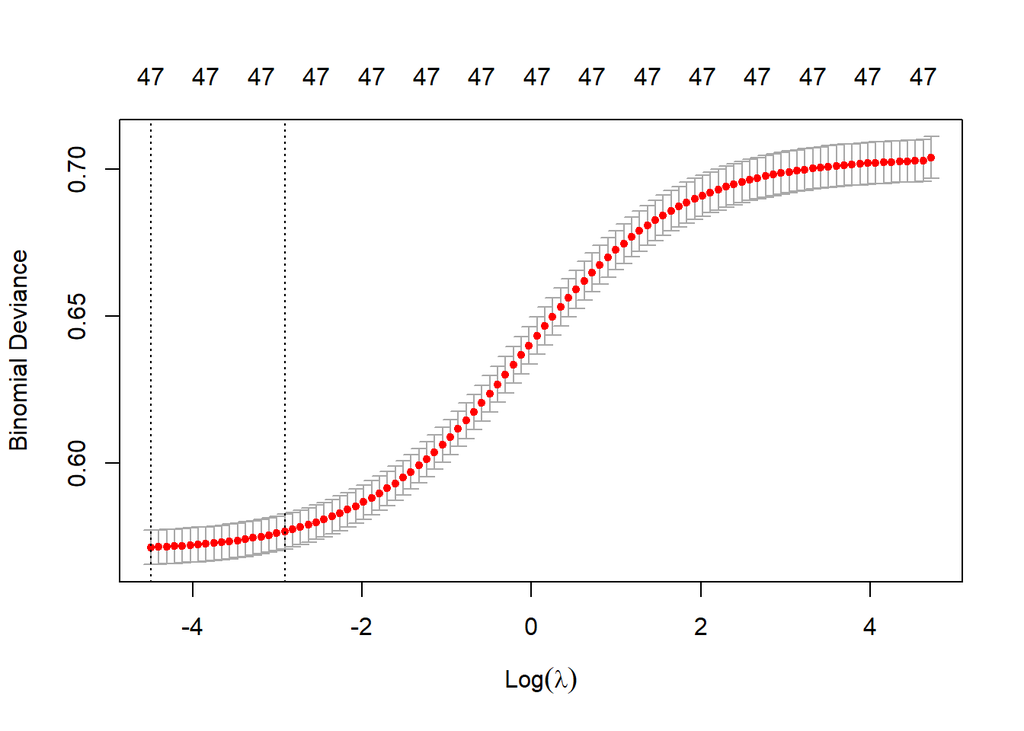

```r
xval <- cv.glmnet(X, y, alpha = 0,family = 'binomial')
plot(xval)
```

```r
# iii random forest, depth control
library(ranger)
bank.rf <- ranger(y ~ .,data = train.df, verbose = F, importance = "impurity")
bank.rf
```

```
## Ranger result
##
## Call:
##  ranger(y ~ ., data = train.df, verbose = F, importance = "impurity")
##
## Type:                             Regression
## Number of trees:                  500
## Sample size:                      37051
## Number of independent variables:  17
## Mtry:                             4
## Target node size:                 5
## Variable importance mode:         impurity
## Splitrule:                        variance
## OOB prediction error (MSE):       0.08013145
## R squared (OOB):                  0.1982529
```

```r
# iv XGBoost
library(xgboost)
X.xgb <- model.matrix(y ~ ., data = train.df)
xgb.cv(data = X.xgb[,-1], label = train.df$y, nrounds = 30, nfold = 10, eta = 1, objective = "binary:logistic", early_stopping_rounds = 3)
```

[output not shown]

```r
bank.xgb <- xgboost(data = X.xgb[,-1], label = train.df$y, nrounds = 6, eta = 1, objective = "binary:logistic")
```

## b)

```r
# i glm prediction
pred.glm <- predict(bank.glm, newdata = test.df, type = "response")
confused.glm <- table(actual = test.df$y, predicted = pred.glm > 0.5)
confused.glm
```

```
##       predicted
## actual FALSE TRUE
##      0  3591   62
##      1   379   84
```

```r
# ii ridge
Xtest <- model.matrix(y ~ ., data = test.df)
ytest <- as.numeric(test.df$y)
pred.ridge <- predict(bank.ridge, Xtest, s = xval$lambda.min)
table(pred.ridge > 0, ytest)
```

```
##        ytest
##            0    1
##   FALSE 3605  393
##   TRUE    48   70
```

```r
confused.ridge <- table(pred.ridge > 0.5, ytest)
confused.ridge
```

```
##        ytest
##            0    1
##   FALSE 3644  440
##   TRUE     9   23
```

```r
# iii) Random forest
pred.rf <- predict(object = bank.rf, data = test.df)
confused.rf <- table(actual = test.df$y, predict = pred.rf$predictions > 0.5)
confused.rf
```

```
##       predict
## actual FALSE TRUE
##      0  3553  100
##      1   338  125
```

```r
# iv) xgboost
test.df.mat <- model.matrix(y ~ ., data = test.df)
pred.xgb <- predict(bank.xgb, newdata = test.df.mat[,-1])
confused.xgb <- table(actual = as.numeric(test.df$y), predicted = pred.xgb > 0.5)
confused.xgb
```

```
##       predicted
## actual FALSE TRUE
##      0  3567   86
##      1   350  113
```

# Task 4

## a)

```r
rf_importance <- sort(bank.rf$variable.importance, decreasing = TRUE)

xgb_importance <- xgb.importance(model = bank.xgb)
xgb_importance <- xgb_importance[order(xgb_importance$Gain, decreasing = TRUE),]
xgb_importance
```

```
##                          Feature         Gain        Cover   Frequency
##  1:                  nr_employed 0.4639351364 7.329218e-02 0.010416667
##  2:                    euribor3m 0.2064109105 2.570667e-01 0.208333333
##  3:                cons_conf_idx 0.0720678048 8.912499e-02 0.031250000
##  4:                          age 0.0473745240 6.289039e-02 0.170138889
##  5:                     campaign 0.0384662790 1.015574e-01 0.142361111
##  6:                     previous 0.0232302619 2.193654e-02 0.020833333
##  7:             contacttelephone 0.0196386219 8.153259e-02 0.024305556
##  8:                     monthoct 0.0195127964 5.997547e-02 0.010416667
##  9:                 emp_var_rate 0.0162402236 8.078766e-03 0.020833333
## 10:               cons_price_idx 0.0118664548 3.434810e-02 0.031250000
## 11:               day_of_weekmon 0.0109466197 2.178171e-02 0.027777778
## 12:               day_of_weekwed 0.0078170505 1.136181e-02 0.017361111
## 13:               defaultunknown 0.0075330181 1.508165e-02 0.010416667
## 14:               maritalmarried 0.0071069173 3.252953e-03 0.034722222
```

[output cut: 30 more lines]

```r
rf_importance[1:6]
```

```
##   euribor3m         age nr_employed         job    campaign   education
##    425.2703    398.8320    233.6464    195.6376    179.7527    171.8854
```

```r
xgb_importance[1:6,]
```

```
##          Feature       Gain      Cover  Frequency
## 1:   nr_employed 0.46393514 0.07329218 0.01041667
## 2:     euribor3m 0.20641091 0.25706673 0.20833333
## 3: cons_conf_idx 0.07206780 0.08912499 0.03125000
## 4:           age 0.04737452 0.06289039 0.17013889
## 5:      campaign 0.03846628 0.10155739 0.14236111
## 6:      previous 0.02323026 0.02193654 0.02083333
```

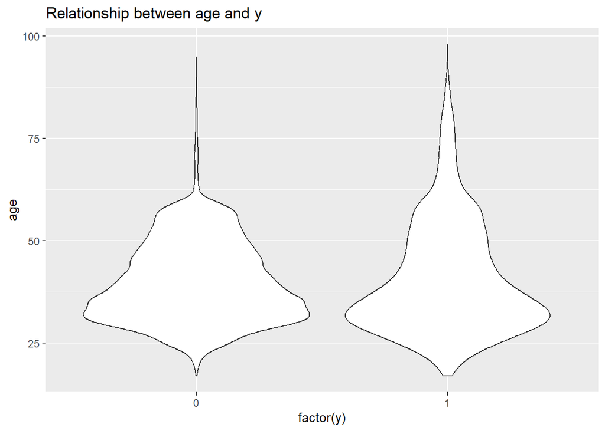

```r
euribo3m_plot <- ggplot(data = bank_edited, aes(x = factor(y), y = age)) +
  geom_violin(scale = "area")  +
  labs(title = "Relationship between age and y")

euribo3m_plot
```

The most importance attributes from the **random forest** models, ranking from the most importance, are: `euribor3m`, `age`, `nr_employed`, `job`, `campaign` and `education`

The most importance attributes from the **xgboost** models, ranking from the most importance, are: `nr_employed`, `euribor3m`, `cons_conf_idx`, `age`, `campaign` and `previous`.

The *common attributes* are: `age`, `euribor3m`, `nr_employed` and `campaign`. The other 4 attributes that are different are: From *random forest*:`job` and `education`, from *xgboost*: `cons_conf_idx` and `previous`.

## b)

```r
#mis_classification = (table[2,1] + table[1,2]) / (table[1,1] + table[1,2] + table[2,1] + table[2,2]), 0.1
# i) mis-classified for glm

mis.glm <- (confused.glm[2,1] + confused.glm[1,2]) / (confused.glm[1,1] + confused.glm[1,2] + confused.glm[2,1] + confused.glm[2,2])

mis.glm
```

```
## [1] 0.1071429
```

```r
# ii) mis-classified for Ridge
mis.ridge <- (confused.ridge[2,1] + confused.ridge[1,2]) / (confused.ridge[1,1] + confused.ridge[1,2] + confused.ridge[2,1] + confused.ridge[2,2])
mis.ridge
```

```
## [1] 0.1090865
```

```r
# iii) mis-classified for random forrest
mis.rf = (confused.rf[2,1] + confused.rf[1,2]) / (confused.rf[1,1] + confused.rf[1,2] + confused.rf[2,1] + confused.rf[2,2])

mis.rf
```

```
## [1] 0.106414
```

```r
# iv) mis- classified for xgboost
mis.xgb = (confused.xgb[2,1] + confused.xgb[1,2]) / (confused.xgb[1,1] + confused.xgb[1,2] + confused.xgb[2,1] + confused.xgb[2,2])

mis.xgb
```

```
## [1] 0.1059281
```

From the mis-classification rate, it seems that most of the models have a relatively low mis-classification rate at around 0.1. This indicate that the models perform relatively similar to each other. I would not choose random forest or xgboost as it is a blackbox modeling, we do not know which features they use and harder to explain. This left with logistic regression and Ridge. In this case, logistic regression could be a better choice as logistic regression is used to model a binary response variable. In addition, logistic regression handle the multilevels categorical variables by creating the dummy variable, in contrast to Ridge where it converted all categorical variables into 0/1 coding in a matrix form. Logistic regression is also easier to interpret as we can interpret the coefficients where we can see the significance of each variables to the response.

## c)

In this analysis, we are interested to predicting if the client will subscribe a term deposit based on different client attributes and social and economic attributes.

In this analysis, we fitted the attributes into 4 different modelling approaches including logistic regression, ridge regression, random forest and XGBoost. Each models are evaluated based on how well they can predicted by calculating the mis-classification rates. The results showed that all of the models performed relatively well as they all have approximately 0.1 mis-classification rates. However, given the attributes of the clients, there are many categorical data, the best modeling approach would be to use the logistic regression as it can handle binary response(yes or no response) relatively well as well as can handle categorical data. Hence, it is recommend to use the logistic regression as the predicting approach in the future.

From this analysis, it is recommend to adjust the marketing approached as the following:

1. We could target a certain jobs such as student and retired clients as we could see that the clients from these two categories have more proportion in subscribing to the term deposit.
2. We could promote the marketing campaing during a certain month. From the analysis, there are more clients subscribed to the term deposit during March, September, October and December.
3. When the Euribor 3 months rate is low and employment variation rate is low, it seems to be the most suitable period to contact customers as there are more likely to subscribe to the term deposit.

EOF